# The RVS (Rare Variant Sharing) Package

Alexandre Bureau, Ingo Ruczinski, Samuel Younkin, Thomas Sherman

10 novembre 2018

#### Package

RVS 1.1.1

# 1 Setting up Pedigree Data

## 1.1 Loading a Pedigree

For this example experiment we will consider four family types. A pair of first cousins, a pair of second cousins, a triple of first cousins, and a triple of second cousins. *RVS* comes with several example pedigrees and these four types can be found in the *samplePedigrees* list.

```r
data(samplePedigrees)

# store the pedigrees
fam_type_A <- samplePedigrees$firstCousinPair
fam_type_B <- samplePedigrees$secondCousinPair
fam_type_C <- samplePedigrees$firstCousinTriple
fam_type_D <- samplePedigrees$secondCousinTriple

# re-label the family ids for this example
fam_type_A$famid <- rep('SF_A', length(fam_type_A$id))
fam_type_B$famid <- rep('SF_B', length(fam_type_B$id))
fam_type_C$famid <- rep('SF_C', length(fam_type_C$id))
fam_type_D$famid <- rep('SF_D', length(fam_type_D$id))
```

## 1.2 Plotting a Pedigree

In order to see the pedigree structure we can use the plot function provided by the *kinship2* package. In this family we have three second cousins that have been sequenced.

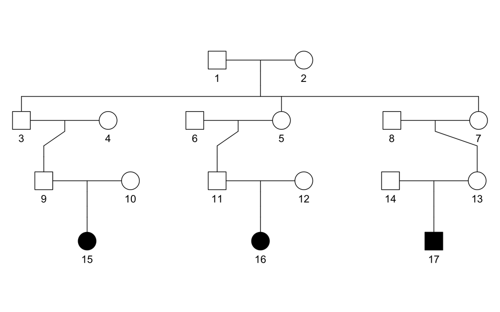

```r
plot(fam_type_D)
```

# 2 Calculating Sharing Probabilities

## 2.1 Sharing Probability for One Family, One Variant

The simplest use of the *RVS* package is to compute the probability that all sequenced subjects in a pedigree share a rare variant, given that it is seen it at least one of the subjects. For more information about this calculation see the documentation for the function *RVsharing* and the Appendix.

In this case we compute the probability for the family of three second cousins. Note that in the case of a single family and variant, the sharing probability can be interpreted as a p-value.

```r
p <- RVsharing(fam_type_D)
```

```
## Probability subjects 15 16 17 among 15 16 17 share a rare variant: 0.001342
```

## 2.2 P-Value for Multiple Families, One Variant

In the case of a single variant seen across multiple families, we can compute the individual sharing probabilities with *RVsharing*, but the sharing probabilities can no longer be interpreted as a p-value for the sharing pattern of the variant across the families. The function *multipleFamilyPValue* can be used to compute the p-value which is defined as the sum of all sharing probabilities across families at most as large as the sharing probability observed.

```r
# compute the sharing probabilities for all families
fams <- list(fam_type_A, fam_type_B, fam_type_C, fam_type_D)
sharing_probs <- suppressMessages(RVsharing(fams))
signif(sharing_probs, 3)
```

```
##    SF_A    SF_B    SF_C    SF_D
## 0.06670 0.01590 0.01180 0.00134
```

```r
# compute p-value for this sharing pattern
sharing_pattern <- c(TRUE, TRUE, FALSE, FALSE)
names(sharing_pattern) <- names(sharing_probs)
multipleFamilyPValue(sharing_probs, sharing_pattern)
```

```
## [1] 0.003343949
```

The *sharing_pattern* vector indicates whether or not the variant is observed in all sequenced subjects.

## 2.3 P-Value for Multiple Families, Multiple Variants

The function *multipleVariantPValue* generalizes *multipleFamilyPValue* across multiple variants. This function takes a *SnpMatrix* instead of a specific sharing pattern. The behavior of this function could be achieved by converting every column of a *SnpMatrix* into a sharing pattern across families and applying *multipleFamilyPValue* across the columns.

The first step is reading in the genotype data. See the *Data Input* [vignette](https://www.bioconductor.org/packages/release/bioc/vignettes/snpStats/inst/doc/data-input-vignette.pdf) in the *snpStats* package for examples using different file types. Here we use a pedigree file in the LINKAGE format. See here for an example of reading genotypes data from a Variant Call Format (VCF) file.

```r
pedfile <- system.file("extdata/sample.ped.gz", package="RVS")
sample <- snpStats::read.pedfile(pedfile, snps=paste('variant', LETTERS[1:20], sep='_'))
```

In this data set we have 3 copies of each family type. The sharing probabilities for this set of families are:

```r
A_fams <- lapply(1:3, function(i) samplePedigrees$firstCousinPair)
B_fams <- lapply(1:3, function(i) samplePedigrees$secondCousinPair)
C_fams <- lapply(1:3, function(i) samplePedigrees$firstCousinTriple)
D_fams <- lapply(1:3, function(i) samplePedigrees$secondCousinTriple)
fams <- c(A_fams, B_fams, C_fams, D_fams)
famids <- unique(sample$fam$pedigree)
for (i in 1:12)
{
    fams[[i]]$famid <- rep(famids[i], length(fams[[i]]$id))
}
sharingProbs <- suppressMessages(RVsharing(fams))
signif(sharingProbs, 3)
```

```
##   SF_A1   SF_A2   SF_A3   SF_B1   SF_B2   SF_B3   SF_C1   SF_C2   SF_C3
## 0.06670 0.06670 0.06670 0.01590 0.01590 0.01590 0.01180 0.01180 0.01180
##   SF_D1   SF_D2   SF_D3
## 0.00134 0.00134 0.00134
```

When we call the function on the genotypes from a *snpMatrix* as follows, it converts them into a sharing pattern assuming the rare variant is the allele with the lowest frequency in the family sample:

```r
result <- multipleVariantPValue(sample$genotypes, sample$fam, sharingProbs)
signif(result$pvalues, 3)
```

```
## variant_A variant_B variant_C variant_D variant_E variant_F variant_G
##  4.44e-03  6.67e-02  1.00e+00  1.00e+00  2.52e-04  1.59e-02  1.00e+00
## variant_H variant_I variant_J variant_K variant_L variant_M variant_N
##  1.00e+00  1.38e-04  1.18e-02  1.00e+00  1.00e+00  1.80e-06  1.34e-03
## variant_O variant_P variant_Q variant_R variant_S variant_T
##  1.00e+00  1.00e+00  1.08e-03  1.00e+00  4.44e-05  1.00e+00
```

The argument *minorAllele* can be used to specify which allele of each variant is the rare variant.

## 2.4 Correcting for Multiple Testing Using Potential P-values

Correcting for multiple testing reduces the cutoff below which a p-value is considered significant. With a large set of variants, it will be impossible to reject the null hypothesis for many of the variants with limited information (e.g. a variant seen in a single small family) because the smallest p-value achievable for that variant is larger than the cutoff. *multipleVariantPValue* provides a filtering option based on the potentia p-values. Potential p-values are the lower bound on the p-value for each variant (Bureau et al. (2014)). In this example we omit any variant whose potential p-values exceeds the cutoff obtained by applying the Bonferroni correction for the number of variants with a sufficiently low potential p-value. In this way, we both increase the p-value cutoff (and hence the power of the test) while maintaining the family-wise error rate at 0.05 and reduce computation time.

```r
result <- multipleVariantPValue(sample$genotypes, sample$fam, sharingProbs, filter='bonferroni', alpha=0.05)
```

The effects of this filter can be seen here. The blue curves show the potential p-value, sorted from most to least significant. It is important to note that these potential p-values are independent of the actual sharing pattern among affected subjects, and therefore of the subsequent testing of variant sharing. The red curve shows the Bonferroni cut-off depending on how many variants are tested. Only 11 variants are included, as sharing here could produce a sharing p-value below the Bonferroni cutoff. The black points show the observed sharing p-values, with six variants being significant after multiple comparisons correction.

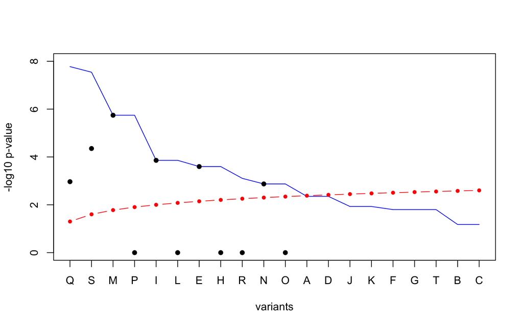

```r
pvals <- result$pvalues
ppvals <- result$potential_pvalues
ppvals_sub <- ppvals[names(pvals)] # subset potential p-values

plot(-log10(ppvals[order(ppvals)]), ylab="-log10 p-value", col="blue", type="l", xaxt="n", xlab="variants", ylim=c(0,8))
xlabel <- sapply(names(ppvals)[order(ppvals)], function(str) substr(str, nchar(str), nchar(str)))
axis(1, at=1:length(ppvals), labels=xlabel)
points(-log10(pvals[order(ppvals_sub)]), pch=20, cex=1.3)
bcut <- 0.05/(1:20)
lines(1:20,-log10(bcut),col="red",type="b",pch=20)
```

## 2.5 Minor Allele Frequency Sensitivity Analysis

When the minor allele frequency (MAF) is known in the population, then an exact sharing probability can be calculated using the *alleleFreq* parameter. Here we analyze the sensitivity of our p-values to the population MAF, using the 3 most significant variants. Note that variants which don’t reach their potential p-values, indicating some families only have partial sharing, are much more sensitive to the MAF.

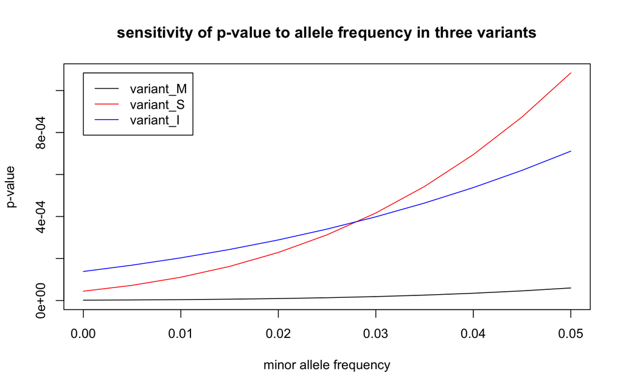

```r
# calculate p-values for each MAF
freq <- seq(0,0.05,0.005)
variants <- names(sort(result$pvalues))[1:3]
pvals <- matrix(nrow=length(freq), ncol=length(variants))
pvals[1,] = sort(result$pvalues)[1:3]
for (i in 2:length(freq))
{
    sharingProbs <- suppressMessages(RVsharing(fams, alleleFreq=freq[i]))
    pvals[i,] <- multipleVariantPValue(sample$genotypes[,variants], sample$fam, sharingProbs)$pvalues
}
colnames(pvals) <- variants

# plot p-values as a function of MAF
plot(NULL, xlim=c(min(freq),max(freq)), ylim=c(0,max(pvals)), type='l',
    xlab="minor allele frequency", ylab="p-value",
    main="sensitivity of p-value to allele frequency in three variants")
lines(freq, pvals[,1], col="black")
lines(freq, pvals[,2], col="red")
lines(freq, pvals[,3], col="blue")
legend(min(freq), max(pvals), legend=colnames(pvals), col=c("black", "red", "blue"), lty=1)
```

## 2.6 Related Founders Correction

When founders of the pedigree are related, the computation is more tricky. *RVS* allows the user to apply a correction for this fact in two different ways. The first way, illustrated below, is a method from Bureau et al. (2014) that uses the mean kinship coefficient among founders to apply a correction. For more details on this calculation see here. The same correction as well as corrections involving any prespecified relationships among founders can be implemented using a Monte Carlo simulation outlined here.

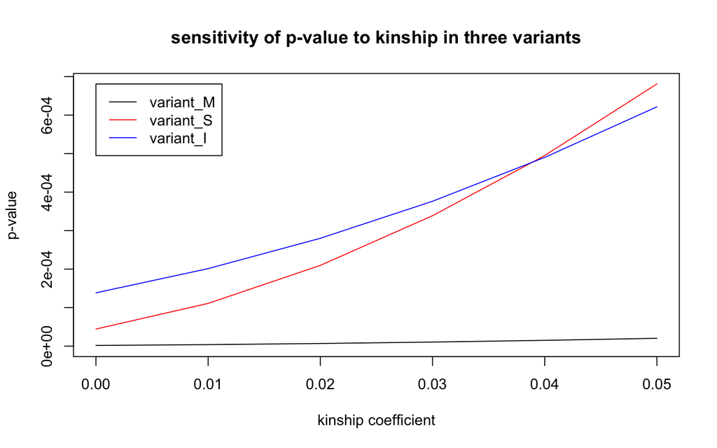

```r
# calculate p-values for each kinship coefficient
kin_coef <- seq(0, 0.05, length=6)
variants <- names(sort(result$pvalues))[1:3]
pvals <- matrix(nrow=length(kin_coef), ncol=length(variants))
pvals[1,] = sort(result$pvalues)[1:3]
for (i in 2:length(kin_coef))
{
    sharingProbs <- suppressMessages(RVsharing(fams, kinshipCoeff=kin_coef[i]))
    pvals[i,] <- multipleVariantPValue(sample$genotypes[,variants], sample$fam, sharingProbs)$pvalues
}
colnames(pvals) <- variants

# plot p-values as a function of kinship
plot(NULL, xlim=c(min(kin_coef), max(kin_coef)), ylim=c(0,max(pvals)), type='l',
    xlab="kinship coefficient", ylab="p-value",
    main="sensitivity of p-value to kinship in three variants")
lines(kin_coef, pvals[,1], col="black")
lines(kin_coef, pvals[,2], col="red")
lines(kin_coef, pvals[,3], col="blue")
legend(min(kin_coef), max(pvals), legend=colnames(pvals), col=c("black", "red", "blue"), lty=1)
```

# 3 Joint analysis of multiple variants

The power of single variant analyses is limited due to the small number of families where a rare variant is seen (often a single family). Even if no individual variant has a significant p-value, it is possible for multiple variants considered across multiple families to exhibit an unusual amount of sharing. The procedure to test multiple rare variants depends whether the variants are far apart or close together in a short genomic region, spanning a single gene for instance.

## 3.1 Enrichment Test

The *enrichmentPValue* function can compute a single p-value for all variants seen in all families assuming the variants are independent. This assumption is reasonable when variants are sufficiently far apart to be unlinked, such as rare deletions scattered over the whole genome as analyzed by Fu et al. (2017). The computation is implemented using a binary tree algorithm described by Fu et al. (2017). When calculating this p-value, note that a very small p-value may result in a very long computation time. Because of this, we can pass a minimum p-value threshold, where the greater of this threshold and the actual p-value will be returned.

```r
enrichmentPValue(sample$genotypes, sample$fam, sharingProbs, 0.001)
```

```
## [1] 0.3989292
```

## 3.2 Gene-based analysis

Joint analysis of rare variants within a gene (typically single nucleotide variants and short indels, possibly filtered based on functional annotations) is another approach to increase statistical power. Here the assumption of independence of rare variants does not hold when variants are seen in the same family, and the solution described by Bureau et al. (2018) and implemented in the *RVgene* function is to keep the variant with the sharing pattern having the lowest probability (usually the variant shared by the largest number of affected relatives in the family). The gene-based analysis with the *RVgene* function is illustrated in section 4.2 along with another new feature: the partial sharing test.

# 4 Partial sharing test

Phenocopies, diagnosis error and intra-familial genetic heterogeneity in complex disorders result in disease susceptibility variants being shared by a subset of affected subjects. In order to detect such causal variants, a partial sharing test was defined by Bureau et al. (2018) where the p-value is the probability of sharing events as or more extreme as the observed event. A more extreme sharing event is defined as having lower probability and involving more carriers of the variant.

## 4.1 Precomputing Sharing Probabilities and Number of Carriers for all Possible Carrier Subsets

In order to perfore the partial sharing test, the *RVgene* function requires the lists *pattern.prob.list* of vectors of sharing probabilities and *N.list* of number of carriers for all possible affected carrier subsets in each family in the sample being analyzed. The arguments of the *RVsharing* function allowing the computation of sharing probabilities by a subset of affected subjects are described here. The elements of both of these lists must have the same names as the pedigree objects in the *ped.listfams* argument. When all affected subjecs in a family are final descendants, the sharing probabilities and number of carriers for all subsets can be generated automatically. Here is an exanple with three second cousins:

```r
carriers = c(15,16,17)
carrier.sets = list()
for (i in length(carriers):1)
carrier.sets = c(carrier.sets, combn(carriers,i,simplify=FALSE))
fam15157.pattern.prob = sapply(carrier.sets,function (vec) RVsharing(samplePedigrees$secondCousinTriple,carriers=vec))
```

```
## Probability subjects 15 16 17 among 15 16 17 share a rare variant: 0.001342
```

```
## Probability subjects 15 16 among 15 16 17 share a rare variant: 0.009396
```

```
## Probability subjects 15 17 among 15 17 16 share a rare variant: 0.009396
```

```
## Probability subjects 16 17 among 16 17 15 share a rare variant: 0.009396
```

```
## Probability subjects 15 among 15 16 17 share a rare variant: 0.3235
```

```
## Probability subjects 16 among 16 15 17 share a rare variant: 0.3235
```

```
## Probability subjects 17 among 17 15 16 share a rare variant: 0.3235
```

```r
fam15157.N = sapply(carrier.sets,length)
```

When the *splitPed* option is *TRUE*, the generation of all carrier subsets is performed within the *RVsharing* function, which then returns the vector of sharing probabilities for all subsets. So the following code is equivalent to the *sapply* of *RVsharing* above:

```r
fam15157.pattern.prob = RVsharing(samplePedigrees$secondCousinTriple,splitPed=TRUE)
```

```
## Founder  1  subped size  17
## Founder  4  subped size  5
## Founder  6  subped size  5
## Founder  8  subped size  5
## Founder  10  subped size  3
## Founder  12  subped size  3
## Founder  14  subped size  3
```

[output not shown]

```r
fam15157.pattern.prob = c(RVsharing(samplePedigrees$secondCousinTriple,carriers=c(15,16,17)),
    RVsharing(samplePedigrees$secondCousinTriple,carriers=c(15,16)),
    RVsharing(samplePedigrees$secondCousinTriple,carriers=c(15)))
```

```
## Probability subjects 15 16 17 among 15 16 17 share a rare variant: 0.001342
```

```
## Probability subjects 15 16 among 15 16 17 share a rare variant: 0.009396
```

```
## Probability subjects 15 among 15 16 17 share a rare variant: 0.3235
```

```r
fam15157.N = 3:1
fam15157.nequiv = c(1,3,3)
```

It is then easy to check that the distribution sums to 1:

```r
sum(fam15157.pattern.prob*fam15157.nequiv)
```

```
## [1] 1
```

When some affected subjects are not final descendants, some subsets are incompatible with a variant being IBD among carriers. Assume individual 3, the grand-father of subject 15 in family 15157, is also affected and his genotype is available.

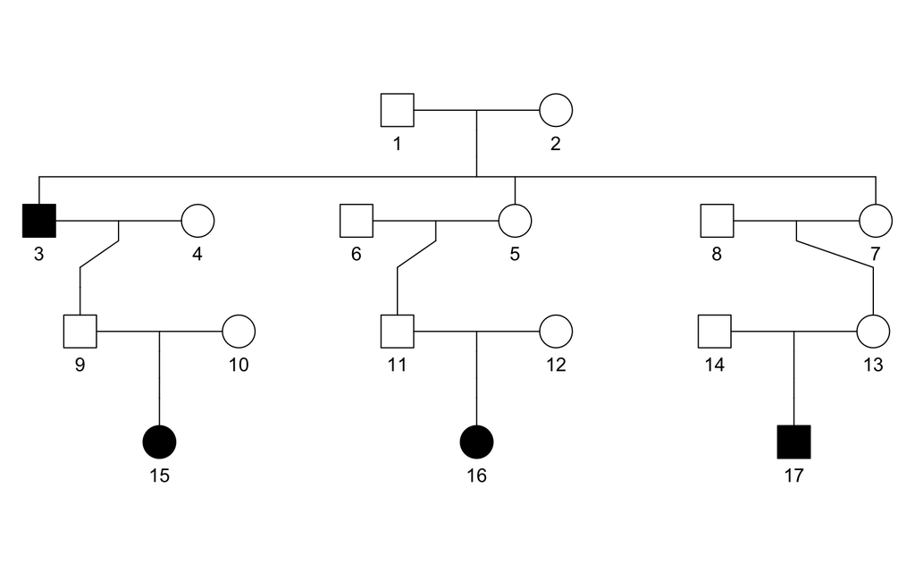

```r
fam15157 <- samplePedigrees$secondCousinTriple
fam15157$affected[3] = 1
plot(fam15157)
```

Then the carrier subsets (15,16,17), (15,16) and (15,17) involving subject 15 but not 3 are incompatible with sharing IBD and must be removed from the list of subsets. The code then becomes:

```r
carriers = c(3,15,16,17)
carrier.sets = list()
for (i in length(carriers):1)
carrier.sets = c(carrier.sets, combn(carriers,i,simplify=FALSE))
carrier.sets
```

```
## [[1]]
## [1]  3 15 16 17
##
## [[2]]
## [1]  3 15 16
##
## [[3]]
## [1]  3 15 17
##
## [[4]]
## [1]  3 16 17
##
## [[5]]
## [1] 15 16 17
##
## [[6]]
## [1]  3 15
##
## [[7]]
## [1]  3 16
##
## [[8]]
## [1]  3 17
##
## [[9]]
## [1] 15 16
##
## [[10]]
## [1] 15 17
##
## [[11]]
## [1] 16 17
##
## [[12]]
## [1] 3
##
## [[13]]
## [1] 15
##
## [[14]]
## [1] 16
##
## [[15]]
## [1] 17
```

```r
carrier.sets = carrier.sets[-c(5,9,10)]
fam15157.pattern.prob = sapply(carrier.sets,function (vec) RVsharing(fam15157,carriers=vec,useAffected=TRUE))
```

```
## Probability subjects 3 15 16 17 among 3 15 16 17 share a rare variant: 0.001121
```

```
## Probability subjects 3 15 16 among 3 15 16 17 share a rare variant: 0.007848
```

```
## Probability subjects 3 15 17 among 3 15 16 17 share a rare variant: 0.007848
```

```
## Probability subjects 3 16 17 among 3 15 16 17 share a rare variant: 0.003363
```

```
## Probability subjects 3 15 among 3 15 16 17 share a rare variant: 0.05493
```

```
## Probability subjects 3 16 among 3 15 16 17 share a rare variant: 0.02354
```

```
## Probability subjects 3 17 among 3 15 16 17 share a rare variant: 0.02354
```

```
## Probability subjects 16 17 among 3 15 16 17 share a rare variant: 0.004484
```

```
## Probability subjects 3 among 3 15 16 17 share a rare variant: 0.1648
```

```
## Probability subjects 15 among 3 15 16 17 share a rare variant: 0.2152
```

```
## Probability subjects 16 among 3 15 16 17 share a rare variant: 0.2466
```

```
## Probability subjects 17 among 3 15 16 17 share a rare variant: 0.2466
```

```r
fam15157.N = sapply(carrier.sets,length)
```

Notice the use of the option *useAffected=TRUE* with affected subjects who are not final descendants. Again, one can check that the distribution sums to 1:

```r
sum(fam15157.pattern.prob)
```

```
## [1] 1
```

Precomputed sharing probabilities and numbers of carriers can be used directly to obtain p-values of observed sharing events, by summing the probability of all events as or more extreme as the one observed (both in terms of sharing probability and number of carriers), i.e. this is a one-sided exact test. For instance, if subjects 3, 16 and 17 share a rare variant, the probability of that event is

```r
pobs = RVsharing(fam15157,carriers=c(3,16,17),useAffected=TRUE)
```

```
## Probability subjects 3 16 17 among 3 15 16 17 share a rare variant: 0.003363
```

The p-value of that sharing event is then:

```r
sum(fam15157.pattern.prob[fam15157.pattern.prob<=pobs & fam15157.N >= 3])
```

```
## [1] 0.004484305
```

The *RVgene* function enables these computations with more than one family harboring the same or different variants. Once the vectors of sharing probabilities and number of carriers have been computed for all families in the sample, they need to be stored in lists. We return to the original second cousin triple family and add a first and second cousin triple family. Then we create the lists of pattern probabilities, number of equivalent subsets and number of carriers in the subsets.

```r
fam15157.pattern.prob = c(RVsharing(samplePedigrees$secondCousinTriple,carriers=c(15,16,17)),
    RVsharing(samplePedigrees$secondCousinTriple,carriers=c(15,16)),
    RVsharing(samplePedigrees$secondCousinTriple,carriers=c(15)))
```

```
## Probability subjects 15 16 17 among 15 16 17 share a rare variant: 0.001342
```

```
## Probability subjects 15 16 among 15 16 17 share a rare variant: 0.009396
```

```
## Probability subjects 15 among 15 16 17 share a rare variant: 0.3235
```

```r
fam15157.N = 3:1
fam15157.nequiv = c(1,3,3)

fam28003.pattern.prob = c(RVsharing(samplePedigrees$firstAndSecondCousinsTriple,carriers=c(36,104,110)),
RVsharing(samplePedigrees$firstAndSecondCousinsTriple,carriers=c(36,104)),
RVsharing(samplePedigrees$firstAndSecondCousinsTriple,carriers=c(104,110)),
RVsharing(samplePedigrees$firstAndSecondCousinsTriple,carriers=c(36)),
RVsharing(samplePedigrees$firstAndSecondCousinsTriple,carriers=c(104)))
```

```
## Probability subjects 36 104 110 among 36 104 110 share a rare variant: 0.00277
```

```
## Probability subjects 36 104 among 36 104 110 share a rare variant: 0.00831
```

```
## Probability subjects 104 110 among 104 110 36 share a rare variant: 0.04155
```

```
## Probability subjects 36 among 36 104 110 share a rare variant: 0.3352
```

```
## Probability subjects 104 among 104 36 110 share a rare variant: 0.3019
```

```r
fam28003.N = c(3,2,2,1,1)
fam28003.nequiv = c(1,2,1,1,2)

ex.pattern.prob.list = list("15157"=fam15157.pattern.prob,"28003"=fam28003.pattern.prob)
ex.nequiv.list = list("15157"=fam15157.nequiv,"28003"=fam28003.nequiv)
ex.N.list = list("15157"=fam15157.N,"28003"=fam28003.N)
```

## 4.2 Example of Analysis of the Rare Variants in the Genomic Sequence of a Gene

We now turn to the analysis of variants observed in the simulated genomic sequence of the gene *PEAR1* in a sample of related affected subjects. The processing of the sequence data results in Variant Call Format (VCF) files, which can be read into R with the function *readVcf* from the *variantAnnotation* package. Two *VCF* objects obtained with *readVcf* from VCF files of sequence data for the second cousin triple and first and second cousin triple families are contained in the *famVCF* data. These VCF files are converted to *snpMatrix* objects using the *genotypeToSnpMatrix* function.

```r
data(famVCF)
fam15157.snp = VariantAnnotation::genotypeToSnpMatrix(fam15157.vcf)
```

```
## non-single nucleotide variations are set to NA
```

```r
fam28003.snp = VariantAnnotation::genotypeToSnpMatrix(fam28003.vcf)
```

```
## non-single nucleotide variations are set to NA
```

*RVgene* requires lists of the *snpMatrix* and *pedigree* objects for these two families. The names given to the elements of these lists are not used by *RVgene* and are thus arbitrary. Family IDs are extracted from the *famid* element of the *pedigree* objects. Please note that currently *RVgene* does not accept a *pedigreeList*, but only a plain list of *pedigree* objects.

```r
ex.SnpMatrix.list = list(fam15157=fam15157.snp$genotypes,fam28003=fam28003.snp$genotypes)
ex.ped.obj = list(fam15157=samplePedigrees$secondCousinTriple,fam28003=samplePedigrees$firstAndSecondCousinsTriple)
```

In the sequence segment, one can specify which variants are rare and possibly satisfy other filtering criteria (e.g. coding variants) using the *sites* argument. Here, we will focus on two sites: 92 where the three second cousins of family 15157 share the rare allele and 119 where the two first cousins of family 28003 share the rare allele but not their second cousin.

```r
sites = c(92,119)
ex.SnpMatrix.list[["fam15157"]][,sites[1]]@.Data
```

```
##    rs187756653
## 1           00
## 2           00
## 3           00
## 4           00
## 5           00
## 6           00
## 7           00
## 8           00
## 9           00
## 10          00
## 11          00
## 12          00
## 13          00
## 14          00
## 15          02
## 16          02
## 17          02
```

```r
ex.SnpMatrix.list[["fam28003"]][,sites[2]]@.Data
```

```
##     rs199628333
## 3            00
## 4            00
## 6            00
## 7            00
## 11           00
## 12           00
## 13           00
## 15           00
## 27           00
## 28           00
## 36           01
## 103          00
## 104          02
## 109          00
## 110          02
```

Finally, the call to *RVgene* returns the P-value of the exact rare variant sharing test allowing for sharing by a subset of affected subjects (p), the P-value of the exact rare variant sharing test requiring sharing by all affected subjects (pall) and the minimum achievable p-value if all affected subjects were carriers of a rare variant (potentialp).

```r
RVgene(ex.SnpMatrix.list,ex.ped.obj,sites,pattern.prob.list=ex.pattern.prob.list,nequiv.list=ex.nequiv.list,N.list=ex.N.list,type="count")
```

```
## $p
## [1] 0.000159884
##
## $pall
## [1] 0.001342282
##
## $potentialp
## [1] 3.718232e-06
```

# 5 Appendix

## 5.1 Rare Variant Sharing Probability Assuming One Founder Introduces the Variant

In this case, we assume the variant is rare enough so that the probability of more than one founder introducing it to the pedigree is negligible. This is the default scenario for *RVsharing*.

We define the following random variables:

*$C_i$: Number of copies of the RV received by subject $i$,

*$F_j$: Indicator variable that founder $j$ introduced one copy of the RV into the pedigree,

For a set of $n$ subjects descendants of $n_f$ founders we want to compute the probability
$$\begin{eqnarray*}
P[\mbox{RV shared}] &=& P[C_1 = \dots = C_n = 1 | C_1 + \dots + C_n \geq 1]
\nonumber \\[0.5em]
&=& \frac{P[C_1 = \dots = C_n = 1 ]}{P[C_1 + \dots + C_n \geq 1]} \nonumber
\\[0.5em]
&=& \frac{\sum_{j=1}^{n_f} P[C_1 = \dots = C_n = 1 | F_j] P[F_j]}
{\sum_{j=1}^{n_f} P[C_1 + \dots + C_n \geq 1 | F_j]P[F_j]},
\label{sharingp}
\end{eqnarray*}$$

where the expression on the third line results from our assumption of a single copy of that RV among all alleles present in the $n_f$ founders. The probabilities $P[F_j] = {1 \over n_f}$ cancel from the numerator and denominator.

## 5.2 Rare Variant Sharing Probabilities for a Subset of Affected Pedigree Members

By default, *RVsharing* will compute the probability that all of the final descendants share the variant given that it is seen in at least one of them. Final descendants are defined as subjects of the pedigree with no children. This event can be customized with the *carriers* and *useAffected* arguments.

If the argument *carriers* is provided, then the probability of all carriers having the variant given it is seen in at least one subject in the union of the final descendants and the carriers will be computed.

If the argument *useAffected* is TRUE and the pedigree has a slot for *affected*, then the probability of all carriers having the variant given it is seen in at least one affected will be computed.

These two arguments can be used individually or in combination, the only restriction is that carriers must be a subset of affected.

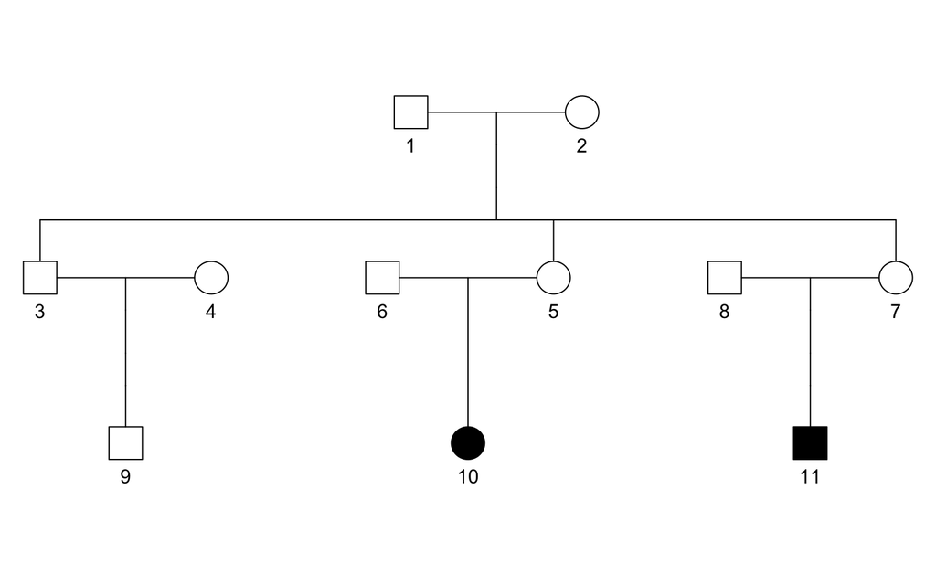

```r
ped <- samplePedigrees$firstCousinTriple
ped$affected[9] <- 0
plot(ped)
```

```r
p <- RVsharing(ped)
```

```
## Probability subjects 9 10 11 among 9 10 11 share a rare variant: 0.01176
```

```r
p <- RVsharing(ped, useAffected=TRUE)
```

```
## Probability subjects 10 11 among 10 11 share a rare variant: 0.06667
```

```r
p <- RVsharing(ped, carriers=c(7,9,10))
```

```
## Probability subjects 7 9 10 among 7 9 10 11 share a rare variant: 0.01064
```

```r
p <- RVsharing(ped, carriers=c(10,11), useAffected=TRUE)
```

```
## Probability subjects 10 11 among 10 11 share a rare variant: 0.06667
```

## 5.3 Using Monte Carlo Simulation

*RVsharing* also allows for estimating sharing probabilities through Monte Carlo simulation. The primary use of this feature is for calculating sharing probabilities under non standard assumptions about the founders. However, this feature is available for the standard assumptions as well. To run a monte carlo simulation, specify all parameters as normal and additionally provide the *nSim* parameter specifying how many simulations should be run.

```r
p <- RVsharing(samplePedigrees$firstCousinPair, alleleFreq=0.01)
```

```
## Probability subjects 7 8 among 7 8 share a rare variant: 0.07631
```

```r
p <- RVsharing(samplePedigrees$firstCousinPair, alleleFreq=0.01, nSim=1e5)
```

```
## Probability subjects 7 8 among 7 8 share a rare variant: 0.07157
```

This method allows for more complex relationships among the founders to be given. *RVsharing* allows for a complete distribution among the founders to be passed in as the parameter *founderDist*. This function should accept a single argument, N, and should return a vector of length N with values in {0,1,2} representing the number of copies of the variant each founder has.

```r
# assumption that 1 founder introduces variant
fDist <- function(N) sample(c(rep(0,N-1), 1))
p <- RVsharing(samplePedigrees$firstCousinPair, nSim=1e5, founderDist=fDist)
```

```
## Probability subjects 7 8 among 7 8 share a rare variant: 0.06752
```

```r
p <- RVsharing(samplePedigrees$firstCousinPair)
```

```
## Probability subjects 7 8 among 7 8 share a rare variant: 0.06667
```

## 5.4 Correcting for Related Founders

### 5.4.1 Computation of Approximate Correction Based on Kinship Coefficient

In this method, a mean kinship coefficient among the founders is passed in with the *kinshipCoeff* parameter. Using the methods from Bureau et al. (2014), *RVsharing* then computes the sharing probability on the assumption one or two founders introduce the variant, weighting each probability using a calculation based on the mean kinship coefficient.

More precisely, an estimation of $P^U$, the probability that a founder alone introduces the rare variant, is obtained from equation (2) of Bureau et al. (2014). Then, $P_2$, the probability that a founder pair introduces the rare variant is obtained from $n_f P_U + {1 \over 2} n_f (n_f-1) P_2 = 1$, where $n_f$ is the number of founders. The corrected rare variant sharing probability is then

$$\begin{eqnarray}
P[\mbox{RV shared}] &=& \label{RVsimplified} \\[0.5em]
&& \frac{ \begin{array}{l} w {1 \over n_f} \sum_{j=1}^{n_f} P[C_1 = \dots =
C_n = 1 | F_j^U] \\ \quad + (1-w) {2 \over n_f (n_f - 1)} \sum_j \sum_{k>j}
P[C_1 = \dots = C_n = 1 | F_j, F_k] \end{array} }{\begin{array}{l}
w {1 \over n_f} \sum_{j=1}^{n_f} P[C_1 + \dots + C_n \geq 1 | F_j^U]\\
\quad + (1-w) {2 \over n_f (n_f - 1)} \sum_j \sum_{k>j} P[C_1 + \dots +
C_n \geq 1 | F_j, F_k] \end{array} } \nonumber
\end{eqnarray}$$

where $w = n_f P_U$. Notice that the above equation corrects equation (3) of Bureau et al. (2014), where the divisions by the number of terms in the summations where missing.

### 5.4.2 Estimating Mean Kinship Coefficient Among Founders

Given the observed kinship between two subjects, $\hat{\phi}_{i,j}$, and the expected kinship , $\phi^p_{i,j}$, it is possible to estimate the mean kinship among the founders, $\hat{\phi^f}_{i,j}$. Averaging this estimate over all sequenced subjects gives a global estimate for the mean kinship coefficient. The relationship is given by:

$\hat{\phi^f}_{i,j} \kappa_{i,j} = \hat{\phi}_{i,j} - \phi^p_{i,j}$

Where $\kappa_{i,j}$ is computed with the function *ComputeKinshipPropCoeff*. This function returns a matrix where the ith row and jth column correspond to $\kappa_{i,j}$.

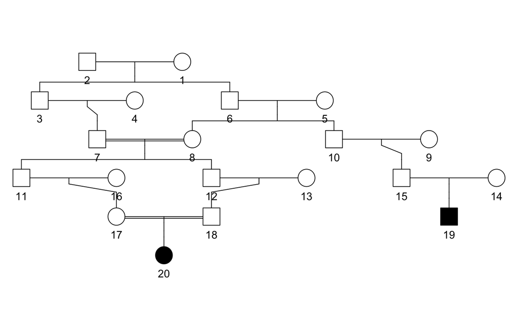

```r
plot(samplePedigrees$twoGenerationsInbreeding)
```

```r
ComputeKinshipPropCoef(samplePedigrees$twoGenerationsInbreeding)
```

```
##           19        20
## 19        NA 0.6757812
## 20 0.6757812        NA
```

# References

Bureau, Alexandre, Ferdouse Begum, Margaret A Taub, Jacqueline Hetmanski, Margaret M Parker, Hasan Albacha-Hejazi, Alan F Scott, et al. 2018. “Inferring Disease Risk Genes from Sequencing Data in Multiplex Pedigrees Through Sharing of Rare Variants.” *Http://Biorxiv.org/Cgi/Content/Short/285874v1*.

Bureau, Alexandre, Samuel G Younkin, Margaret M Parker, Joan E Bailey-Wilson, Mary L Marazita, Jeffrey C Murray, Elisabeth Mangold, Hasan Albacha-Hejazi, Terri H Beaty, and Ingo Ruczinski. 2014. “Inferring Rare Disease Risk Variants Based on Exact Probabilities of Sharing by Multiple Affected Relatives.” *Bioinformatics (Oxford, England)* 30 (15): 2189–96. doi:10.1093/bioinformatics/btu198.

Fu, Jack, Terri H Beaty, Alan F Scott, Jacqueline Hetmanski, Margaret M Parker, Joan E Bailey Wilson, Mary L Marazita, et al. 2017. “Whole Exome Association of Rare Deletions in Multiplex Oral Cleft Families.” *Genetic Epidemiology* 41 (1): 61–69. doi:10.1002/gepi.22010.